# NLP4RE Tools Sampling

Anonymous

2026-01-28

This notebook draws a random sample from the list of NLP4RE tools.

## Data Preparation

First, we load the data produced by Frattini et al.[^1]

```r
d <- read_tsv("data/nlp4re-tools.tsv", skip = 2)
```

Next, we parse the data and cast all relevant variables to their respective form.

```r
# specification of all categories
#c.license <- c("MIT", "CC2.0", "None", "Apache 2.0", "Unknown", "CC4.0", "GPL3.0",
#               "EPL", "MS-RSL", "MPL-2.0", "CC0", "BSD-2-Clause")
c.availability <- c("Proprietary", "Private", "Unavailable", "Broken",
                    "Upon Request", "Reachable", "Open Source", "Archived")
c.activity <- c("Elicitation", "Analysis", "Modeling", "Validation & Verification",
                  "Management", "Other", "Multiple")
c.task <- c("Detection", "Extraction", "Classification", "Transformation",
            "Tracing & Relating", "Search & Retrieval", "Generation")

d <- d %>%
  mutate(
    Verdict = factor(Verdict, levels = c("included", "excluded"), ordered = FALSE),
    #License = factor(License, levels = c.license, ordered = FALSE),
    Availability = factor(Availability, levels = c.availability, ordered = TRUE),
    Activity = factor (`RE Activity`, levels = c.activity, ordered = FALSE),
    Task = factor(`Tool Task`, levels = c.task, ordered = FALSE)
  ) %>%
  select(ID, Verdict, Name, `Source Code`, Availability, Activity, Task)

str(d)
```

```
## tibble [202 × 7] (S3: tbl_df/tbl/data.frame)
##  $ ID          : chr [1:202] "R001" "R002" "R003" "R004" ...
##  $ Verdict     : Factor w/ 2 levels "included","excluded": 2 1 2 2 1 2 2 2 1 2 ...
##  $ Name        : chr [1:202] NA "OpenReq-DD (dependency detection)" NA NA ...
##  $ Source Code : logi [1:202] FALSE TRUE FALSE FALSE FALSE FALSE ...
##  $ Availability: Ord.factor w/ 8 levels "Proprietary"<..: NA 7 NA NA 3 NA NA NA 7 NA ...
##  $ Activity    : Factor w/ 7 levels "Elicitation",..: NA 5 NA NA 1 NA NA NA 5 NA ...
##  $ Task        : Factor w/ 7 levels "Detection","Extraction",..: NA 5 NA NA 3 NA NA NA 3 NA ...
```

We need to apply some inclusion criteria, namely:

1. Only consider articles that presented an NLP4RE tool.
2. Only consider tools where the source code is available.
3. Only consider tools that are available (i.e., their `Availability` is `Reachable`, `Open Source`, or `Archived`).

```r
df <- d %>%
  filter(
    Verdict == "included",
    `Source Code` == TRUE,
    Availability %in% c("Reachable", "Open Source", "Archived")
  )
```

For later comparison, we visualize the distribution of the three determining variables *Availability*, *Activity*, and *Task* in the population.

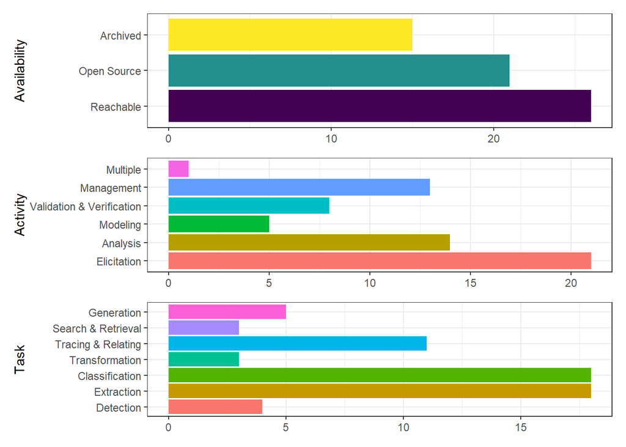

```r
visualize_distribution <- function(data, attribute) {
  plt.availability <- ggplot(data, aes(y = .data[[attribute]], fill = .data[[attribute]])) +
    geom_bar() +
    theme_bw() +
    theme(axis.title.x = element_blank()) +
    guides(fill = "none") +
    scale_x_continuous(labels = scales::number)

  return(plt.availability)
}

visualize_distributions <- function(data) {
  plt.availability <- visualize_distribution(data, "Availability")
  plt.activity <- visualize_distribution(data, "Activity")
  plt.task <- visualize_distribution(data, "Task")

  plt.availability / plt.activity / plt.task
}

visualize_distributions(df)
```

## Sampling

With the data prepared, we draw a random sample of size `sample.size` from the eligible NLP4RE tools. We visually assess whether the distribution of the three relevant factors *Availability*, *Activity*, and *Task* in the subset is equal to the distribution to the overall population.

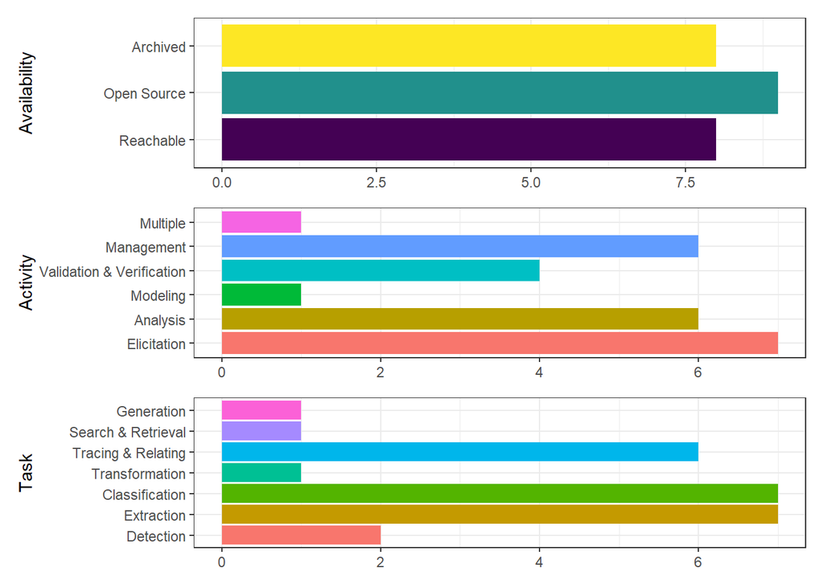

```r
set.seed(8) # other eligible candidates: 4
sample.size = 25

sampled.id <- sample(df$ID, size = sample.size, replace = FALSE)
dfs <- df %>% filter(ID %in% sampled.id)

visualize_distributions(dfs)
```

Visually, these distributions are fairly equal, meaning that the subset preserves the distribution of the population. Hence, the following selection of tools can be used for the traceability mapping method.

```r
#print(dfs %>% select(ID, Name, Availability, Activity, Task), n = sample.size)
print(dfs %>% select(ID, Availability, Activity, Task), n = sample.size)
```

```
## # A tibble: 25 × 4
##    ID    Availability Activity                  Task
##    <chr> <ord>        <fct>                     <fct>
##  1 R002  Open Source  Management                Tracing & Relating
##  2 R012  Reachable    Analysis                  Extraction
##  3 R014  Reachable    Management                Classification
##  4 R017  Reachable    Validation & Verification Extraction
##  5 R018  Archived     Modeling                  Tracing & Relating
##  6 R024  Archived     Management                Tracing & Relating
##  7 R028  Archived     Validation & Verification Classification
##  8 R032  Open Source  Elicitation               Classification
##  9 R039  Reachable    Elicitation               Classification
## 10 R046  Archived     Elicitation               Search & Retrieval
## 11 R066  Reachable    Analysis                  Classification
## 12 R094  Open Source  Management                Tracing & Relating
## 13 R103  Reachable    Elicitation               Extraction
## 14 R108  Archived     Management                Tracing & Relating
## 15 R113  Open Source  Multiple                  Classification
## 16 R124  Open Source  Analysis                  Detection
## 17 R125  Archived     Validation & Verification Transformation
## 18 R129  Open Source  Analysis                  Detection
## 19 R137  Reachable    Management                Tracing & Relating
## 20 R149  Archived     Validation & Verification Classification
## 21 R155  Open Source  Elicitation               Extraction
## 22 R161  Open Source  Elicitation               Extraction
## 23 R166  Open Source  Elicitation               Extraction
## 24 R176  Reachable    Analysis                  Generation
## 25 R186  Archived     Analysis                  Extraction
```

## Re-Sampling

Two of the selected tools are no longer available:

1. The anaphoric ambiguity detector by Ezzini et al.[^2] was originally available at https://gitlab.uni.lu/sabualhaija/anaphoric-ambiguity but the URL no longer resolves.
2. ScenarioAmigo by Ko et al.[^3] was originally available at https://github.com/maniara/ScenarioAmigo but the repository is no longer available on GitHub.

We re-sample from the remaining data but try to preserve the distribution of the sample. The anaphoric ambiguity detector was classified as supporting the *analysis* activity with a *detection* task. The C&L tool mirrors these properties, and therefore, is an adequate replacement.

```r
df %>%
  filter(!(ID %in% dfs$ID) & (Activity == "Analysis") & (Task == "Detection")) %>%
  select(ID, Name, Availability, Activity, Task)
```

```
## # A tibble: 1 × 5
##   ID    Name  Availability Activity Task
##   <chr> <chr> <ord>        <fct>    <fct>
## 1 R170  C&L   Reachable    Analysis Detection
```

ScenarioAmigo was classified as supporting the *analysis* activity with a *generation* task. Sadly, no other tool matches this configuration. Since *generation*-task tools are rare, we prioritize this property. Additionally, ScenarioAmigo was *reachable*, which we can also preserve.

```r
df %>%
  filter(!(ID %in% dfs$ID) & (Availability == "Reachable") & (Task == "Generation")) %>%
  select(ID, Name, Availability, Activity, Task)
```

```
## # A tibble: 2 × 5
##   ID    Name                   Availability Activity    Task
##   <chr> <chr>                  <ord>        <fct>       <fct>
## 1 R038  Domain model extractor Reachable    Elicitation Generation
## 2 R086  DBRG                   Reachable    Elicitation Generation
```

Among the two possible choices, we select DBRG since it it implemented in Java, which is under-represented in our sample.

[^1]: Frattini, J., Unterkalmsteiner, M., Fucci, D., & Mendez, D. (2025). NLP4RE Tools: Classification, Overview and Management. In Handbook on Natural Language Processing for Requirements Engineering (pp. 357-380). Cham: Springer Nature Switzerland.
[^2]: Ezzini, S., Abualhaija, S., Arora, C., & Sabetzadeh, M. (2022, May). Automated handling of anaphoric ambiguity in requirements: a multi-solution study. In Proceedings of the 44th International Conference on Software Engineering (pp. 187-199).
[^3]: Ko, D., Kim, S., & Park, S. (2019). Automatic recommendation to omitted steps in use case specification. Requirements Engineering, 24, 431-458.